# Rat risk predict model

113048230洪振傑、113048116凌沛瀅、113042045饒葳、112070021吳玟萱

2026-06-04

## Abstract

此階段將以資料預處理後的台北市各里data為分析單位，目標變數為每千人鼠患通報率（mouse_per1k）。由於資料具有明顯的右偏分布與 Zero-Inflation 特性，因此在特徵工程階段對餐飲業密度、食物相關業面積密度與人口密度進行 log 轉換，並加入傳統市場數與餐飲業密度的交互特徵，共產出 15 個特徵。  
本研究透過Python 語言環境來建立模型。資料切分部分，首先依據有/無鼠患後進行資料分層後（以 60/40 切分）且比較兩種模型：以 Tweedie 損失函數天然處理零值的 XGBoost模型，以及對目標變數進行 log(y+1) 轉換後訓練的 Random Forest(隨機森林）模型。針對模型成果採 5-fold Stratified Cross-Validation 產出 OOF （ Out-of-Fold，折外預測）以評估泛化能力，同時以 Naive Mean 作為基準線進行比較。  
本研究採用隨機森林（Random Forest）作為最終預測模型。Random Forest 是一種集成學習方法，透過 Bootstrap Sampling 建構 500 棵獨立的決策樹，每棵樹訓練於不同的資料子集，並以均方誤差（MSE）最小化作為分裂準則，同時隨機抽取特徵子集（約 4 個）以增加多樣性。最終預測值為所有樹的平均輸出。為處理目標變數 mouse_per1k 的右偏與零膨脹問題，訓練前進行 log(1+y) 轉換，預測後還原。  
最終，本研究選定 Random Forest 為主模型，並依其 OOF 預測值的分位數設定低、中、高三級風險切點，對全體里進行風險分級。最終模型可達成輔助巡查優先順序與資源配置的決策用途。

## perparing for building model

## EDA(Explornary Data Analysis) of target variable

依照本研究欲預測鼠患風險目標，於此設定目標變數為mouse_per1k，即每千人鼠患通報率，可用於反應該地區鼠患嚴重情形，並以里為觀察單位。然而，許多里的通報率為0而造成該變數具有明顯的**零膨脹（Zero-Inflation）**特性，導致其分布呈現強烈右偏，少數高通報率里拉高了均值與標準差，中位數遠低於均值，因此在後續模型選擇與轉換策略上將特別處理。

## Faeture Engineering 特徵工程

本次研究中進行以下特徵工程：  
• 從原始資料中選取 11 個環境特徵  
• **排除mouse_n及行政代碼欄位**：前者為目標分子，會造成 data leakage，後者則是單純方便使用  
• **log_restaurant_per1k = log(1 + restaurant_per1k)** :修正右偏分布  
• **og_food_km2 = log(1 + food_total_per_km2)** :修正右偏分布  
• **log_pop_density = log(1 + pop_density)** :修正右偏分布  
• **market_x_food = market_n × restaurant_per1k** :市場與餐飲的交互效應  
• **定義spatial_lag_mouse=鄰近里平均鼠患率** :考量老鼠的群集性，以鄰接的其他里每千人鼠患通報率（mouse_per1k）取平均，呈現該里潛在鼠患潛在風險。

## Train / Test Split（60 / 40）

```
X_tr, X_te, y_tr, y_te, yb_tr, yb_te = train_test_split(
    X, y, y_binary,
    test_size=0.4, stratify=y_binary, random_state=42
)
```

採用 train_test_split並以有無鼠患通報（二元標籤）進行分層抽樣（stratify），確保訓練集與測試集在零值比例上保持一致，避免分割偏差。最終以 60% 作為訓練集、40% 作為測試集。

```
============================================================
STEP 3  Train / Test Split（60/40，依有無鼠患分層）
============================================================
  Train：273 筆  |  Test：183 筆
  Train Zero%：30.8%  Test Zero%：30.6%
============================================================
```

根據切分結果:  
•Train：273 筆  
•Test：183 筆  
•Train Zero%：30.8%  
•Test Zero%：30.6%

## model training 模型訓練

考量本研究目標以及可使用資料數量，選擇 Random Forest 與 XGBoost 兩種樹模型進行比較，主要原因如下：本研究目的並非追求精確預測每千人鼠患通報率的數值，而是希望辨識出「高風險里」以協助巡查資源分配，因此需要的是對特徵與風險之間「非線性關係」與「交互作用」具備良好捕捉能力的模型。傳統線性迴歸（OLS）難以處理零膨脹與右偏分布，也無法表達餐飲密度、市場數與人口密度之間的交互效應；深度學習模型則需要大量樣本訓練，而本研究訓練集僅約 273 筆里資料，樣本量明顯不足，易導致嚴重過擬合且難以收斂。相對地，樹模型在小樣本與表格型資料上表現穩定、對特徵尺度不敏感、能自動處理特徵互動，並提供可解釋的特徵重要性，符合本研究決策支援的需求。其中 Random Forest 採 Bagging 平均策略，泛化穩定；XGBoost 採 Boosting 串行修正並支援 Tweedie 損失，可天然處理零膨脹分布，兩者各具優勢。

### Random Forest 核心機制

Random Forest 透過下列機制組合而成：  
(1) **Bootstrap Sampling**:每棵樹從 273 筆訓練資料中有放回抽取 273 筆（約 63% 不重複），500 棵樹各自看到不同樣本；  
(2) **節點分裂準則**:以最小化均方誤差作為「損失函數」，讓葉節點內 mouse_per1k 值盡量接近，直到觸及 max_depth=6 或 min_samples_leaf=8；  
(3) **Random Feature Selection**:每次分裂僅從 15 個特徵中隨機抽 √15 ≈ 4 個尋找最佳切點，避免強特徵主導所有樹

### XGBoost 模型運作簡介

XGBoost (eXtreme Gradient Boosting) 屬於 Boosting 集成方法，與 Random Forest 的「平行獨立建樹再平均」不同，XGBoost 採用「逐棵串行修正」策略：  
(1) 先以一個初始預測值（通常為目標平均）出發，計算每筆樣本的殘差（梯度）；  
(2) 每一輪訓練一棵新樹去擬合上一輪的殘差，並乘上學習率 (learning_rate) 後加回前一輪的預測，逐步修正誤差；  
(3) 目標函數同時包含損失項與正則化項（L1/L2 與葉節點數懲罰），以控制模型複雜度、抑制過擬合；  
(4) 本研究選用 Tweedie 損失函數 (variance_power=1.5)，可天然處理零膨脹且右偏的 mouse_per1k，無需額外做 log 轉換;最終預測值為所有樹輸出的加總。

因此本研究建立兩個模型進行比較：  
模型 A — **Random Forest（隨機森林）**  
對目標變數做 log(1+y) 轉換後訓練，預測時再用 exp(pred) - 1 還原。使用 500 棵樹、最大深度 6、每節點最少 8 個樣本、每次分裂抽 √特徵數 個特徵。

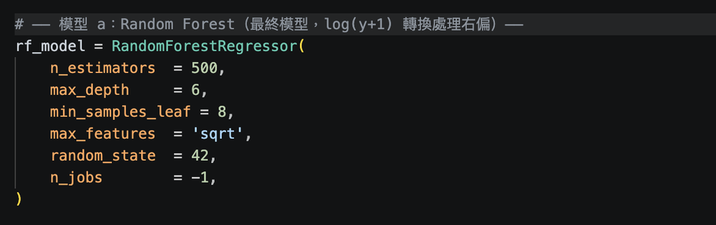

模型 B — **XGBoost Tweedie**  
使用 Tweedie 損失函數[^1]，variance_power=1.5，天然支援零膨脹的連續分布，learning rate 取0.03，max_depth 取4。

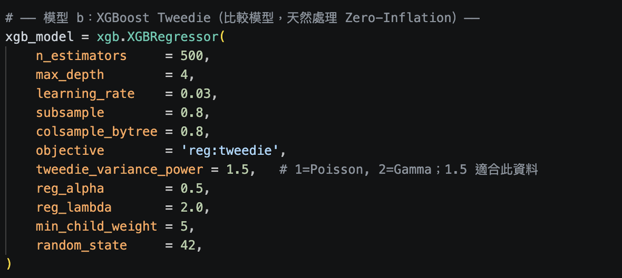

## 評估model performance & Overfitting 檢查

根據輸出結果，如下圖所示：

```
Train 表現（參考用，不代表泛化能力）：
          Model      MAE     RMSE       R²  Spearman
XGBoost Tweedie 0.108325 0.146897 0.909359  0.907436
  Random Forest 0.225314 0.383899 0.380943  0.691432

  Test 表現（真實泛化估計）：
          Model      MAE     RMSE        R²  Spearman
XGBoost Tweedie 0.263973 0.395061  0.073243  0.271197
  Random Forest 0.257382 0.385418  0.117934  0.320641
     Naive Mean 0.289316 0.411519 -0.005579       NaN
```

比較 XGBoost Tweedie 與 Random Forest 兩種模型在鼠患通報率（mouse_per1k）預測任務上的表現。就訓練集而言，XGBoost Tweedie 呈現極高的擬合能力（Train R² = 0.909、MAE = 0.108），然而測試集表現大幅下滑（Test R² = 0.073、MAE = 0.264），訓練/測試 MAE 比值達 2.44，顯示該模型有明顯的過擬合（Overfitting）現象，不具備良好的泛化能力。  
相較之下，Random Forest 的訓練集表現雖較為保守（Train R² = 0.381），但測試集指標衰退幅度有限（Test R² = 0.118、MAE = 0.257），訓練/測試 MAE 比值僅 1.14，反映出較穩健的泛化特性。此外，兩個模型在測試集的 MAE 均優於 Naive Mean 基準（MAE = 0.289），確認模型確實從特徵中學習到有效的預測資訊。

```
 XGBoost Tweedie         Train MAE=0.1083  Test MAE=0.2640  Ratio=2.44  ⚠️  過擬合明顯
  Random Forest           Train MAE=0.2253  Test MAE=0.2574  Ratio=1.14  ✅ 尚可接受
```

同樣根據overfitting的檢查，以訓練集與測試集 MAE 之比值（Overfitting Ratio）作為過擬合診斷依據，XGBoost Tweedie 之比值為 2.44，顯示明顯過擬合；Random Forest 之比值僅為 1.14，泛化能力較佳，故同樣呈現出選用 Random Forest 作為最終預測模型。  
綜合以上分析，可知 Random Forest較為適合作為最終模型，以其較低的過擬合風險及較高的 Spearman 排序相關（0.321）作為鼠患風險分級的預測依據。

## 5-fold Stratified Cross-Validation（OOF）

```
  Fold 1:  XGB MAE=0.2767  RF MAE=0.2483
  Fold 2:  XGB MAE=0.2993  RF MAE=0.2992
  Fold 3:  XGB MAE=0.3029  RF MAE=0.2749
  Fold 4:  XGB MAE=0.2618  RF MAE=0.2423
  Fold 5:  XGB MAE=0.2366  RF MAE=0.2545

                Model      MAE     RMSE       R²  Spearman
(Baseline) Naive Mean 0.311550 0.458627 0.000000       NaN
 XGBoost Tweedie  OOF 0.275462 0.427492 0.131165  0.309831
 Random Forest    OOF 0.263800 0.419652 0.162742  0.369710
```

以 Out-of-Fold（OOF）預測值計算各項指標。Random Forest 在五個 Fold 中有四個優於 XGBoost Tweedie，OOF MAE 為 0.2638，較僅以均值預測的基準模型（MAE = 0.3116）提升 15.3%，R² 為 0.163，Spearman 排序相關達 0.370。雖然 R² 數值偏低，但考量目標變數具有 Zero-Inflation 特性且特徵解釋力有限，此結果屬合理範圍。Spearman 相關係數反映模型對高鼠患風險里具備中等程度的排序能力，足以支持高、中、低風險分級的政策應用目的。

## Feature importance

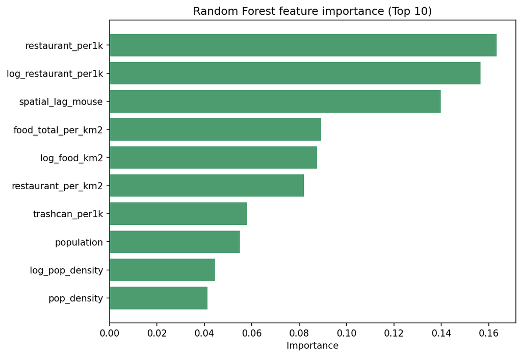

## 風險分級

於此，以 Random Forest 模型的Out-of-Fold（OOF）預測值作為風險分級依據。模型對每個里輸出一個連續的預測鼠患通報率（mouse_per1k），再依據預測值的分位數設定兩個切點：(如下圖）  
以非零預測值的第 33 百分位數（0.222）為低風險與中風險之分界，以第 75 百分位數（0.365）為中風險與高風險之分界，最終將台北市 456 個里分為低風險（151 里，33.1%）、中風險（191 里，41.9%）及高風險（114 里，25.0%）三個等級。採用分位數切點而非固定絕對值，目的在於確保各風險等級皆有足夠樣本數，避免因資料分布不均造成分級失衡。

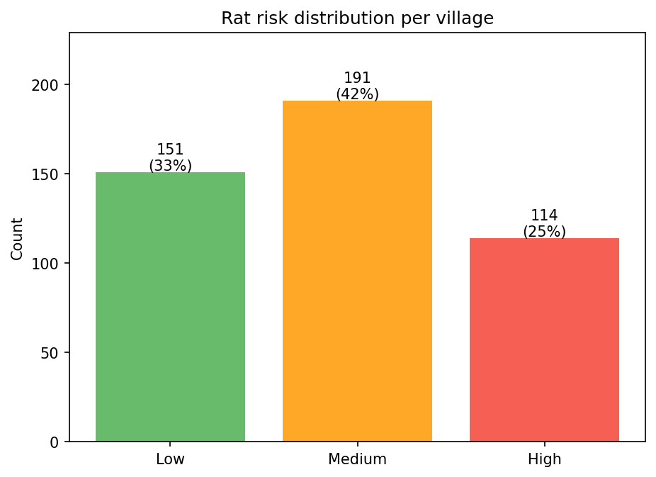

```
 切點設定：低/中 = 0.222  中/高 = 0.365
  （閾值說明：低<中閾，中閾≤預測<高閾，高閾以上為高風險）

  風險分布：
risk
低風險    151
中風險    191
高風險    114
Name: count, dtype: int64

  分類報告（OOF 預測 vs 實際分位數切點）：
              precision    recall  f1-score   support

         低風險       0.67      0.46      0.55       219
         中風險       0.21      0.50      0.30        80
         高風險       0.61      0.44      0.51       157

    accuracy                           0.46       456
   macro avg       0.49      0.47      0.45       456
weighted avg       0.57      0.46      0.49       456
```

根據分類報告顯示，rf模型整體準確率為 0.46，其中低風險（Precision = 0.67）與高風險（Precision = 0.61）的辨識精準度相對較佳，中風險因與其他等級的邊界模糊而表現較弱（Precision = 0.21）。此結果符合預期：模型在識別極端值（幾乎無鼠患 vs. 明顯高鼠患）上具有較高信心，而位於中間地帶的里則較難判斷，反映了目標變數 Zero-Inflation 與特徵解釋力有限的固有限制。

## 情境模擬 Demo

透過前文所建立的random Forest隨機森林模型，筆者在將模型與實際台北市各里資料做real/predict的比較以及風險級別的label。（如下表所示）

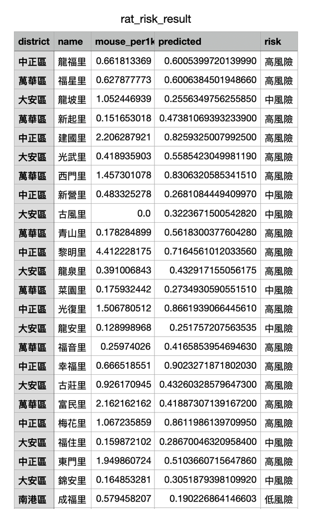

同時，為驗證模型的實際應用可行性，本研究設計五種代表性都市情境，模擬不同環境條件下的鼠患風險預測，各情境特徵輸入值如下表所示：

| 特徵 | 夜市商業高密度 | 老城區傳統市場 | 新興住宅區 | 低密度郊區 | 山區低人口里 |
| --- | --- | --- | --- | --- | --- |
| restaurant_per1k | 15.0 | 10.0 | 3.0 | 1.0 | 0.0 |
| food_total_per_km2 | 400 | 250 | 60 | 15 | 5 |
| market_n | 2 | 1 | 0 | 0 | 0 |
| trashcan_per1k | 4.0 | 2.5 | 0.8 | 0.3 | 0.0 |
| spatial_lag_mouse | 0.80 | 0.60 | 0.20 | 0.10 | 0.05 |
| oldtown_density | — | 1.5 | — | — | — |
| pop_density | 25,000 | 20,000 | 15,000 | 3,000 | 800 |

其輸出結果如下：結果顯示，餐飲業密度高、空間鄰里鼠患指數（spatial lag）較大的情境（如夜市商業高密度、老城區傳統市場）均被預測為高風險；而人口稀少、餐飲密集度低的情境（如低密度郊區、山區低人口里）則被歸為低風險。情境預測結果與直覺認知高度一致，顯示模型所學習的特徵與目標變數之間的關聯符合現實邏輯，具備作為政府防治資源配置參考工具的潛力。

```
情境                        預測值     風險等級
  ----------------------------------------
  夜市商業高密度                 0.709  🔴高風險
  老城區傳統市場                 0.629  🔴高風險
  新興住宅區                   0.227  🟡中風險
  低密度郊區                   0.142  🟢低風險
  山區低人口里                  0.141  🟢低風險
```

## 研究限制與後記

作為針對時事議題而出發的模型，礙於資料來源限制需仰賴人工通報以及彙整，因此仍無法達到百分百掌握實際鼠患情形。同時模型的預測準確率能有許多進步空間，目前僅能針對部分特徵做出鼠患中高風險情形預估，試圖降低忽略鼠患嚴重的任何可能。因此未來在公為以及防疫上，仍須仰賴人工搜集資料與掌握實地情形，方可使模型更加進步，並作為對抗鼠患之利器。

[^1]: Tweedie 損失函數是一種專門用於「大量零值」與「連續正值」混合資料的機器學習迴歸損失函數。它源自於 Tweedie 機率分布（複合卜瓦松-伽瑪分布），在預測保險理賠金額、廣告點擊收益等常出現「零損失」且右偏長尾的實際業務場景中極為常用。